# Assignment03 QUANT

jtang

9/24/2020

## Libraries

```r
library(tidyverse)
library(ggplot2)
library(gridExtra)

# Did not end up using this:
library(skimr)
```

## Data

```r
all_hh <- read_csv("all_hh.csv") %>%
  filter(HINCP > 0,
         HINCP <= 200000)

hh_rent <- all_hh %>%
  filter(TEN_label == "Rented")

hh_own <- all_hh %>%
  filter(!TEN_label == "Rented",
         !TEN_label == "Occupied without payment of rent",
         !TEN_label == "N/A (GQ/vacant)")
```

## Notes

Things I did not get to based on Monday’s feedback:

- Overlay scatterplots in different colors and look at Cristina Gonzalez’s code for reference
- Explore the `skimr` library, a suggestion from Jennifer Horowitz to see medians within categories… but would that give me the significance of these medians within categories? Is there a two-sample t-test for medians?
- Would I do a chi-square test for two multi-level categorical variables?k
- Need to look into how to rename all strings that say *really long string*. Probably covered in Carole’s tutorial somewhere.
- If I were ambitious, I could create a table comparing the strengths of relationships and their significances across variable combinations.
- For chi-square tests, maybe I should write something that calculates difference between observed and expected?

Things I did not get to, period:

- Interpreting TukeyHSD results

Other Notes:

## I. Two Cont.

### Income, Housing Cost

- 3 buckets: All Households; Renter HHs; Owner HHs

#### Test

Significant relationships:

- There is a stronger positive correlation between Income and Housing Cost for Rented HHs than for Owner HHs. Neither correlations are particularly strong.

```r
correla_all_hh <- cor.test(all_hh$HC, all_hh$HINCP)
correla_all_hh
```

```
##
##  Pearson's product-moment correlation
##
## data:  all_hh$HC and all_hh$HINCP
## t = 160.83, df = 156832, p-value < 2.2e-16
## alternative hypothesis: true correlation is not equal to 0
## 95 percent confidence interval:
##  0.3720049 0.3805019
## sample estimates:
##       cor
## 0.3762613
```

```r
correla_hh_rent <- cor.test(hh_rent$HC, hh_rent$HINCP)
correla_hh_rent
```

```
##
##  Pearson's product-moment correlation
##
## data:  hh_rent$HC and hh_rent$HINCP
## t = 125.01, df = 55733, p-value < 2.2e-16
## alternative hypothesis: true correlation is not equal to 0
## 95 percent confidence interval:
##  0.4614498 0.4744181
## sample estimates:
##       cor
## 0.4679591
```

```r
correla_hh_own <- cor.test(hh_own$HC, hh_own$HINCP)
correla_hh_own
```

```
##
##  Pearson's product-moment correlation
##
## data:  hh_own$HC and hh_own$HINCP
## t = 113.99, df = 101097, p-value < 2.2e-16
## alternative hypothesis: true correlation is not equal to 0
## 95 percent confidence interval:
##  0.3319970 0.3429214
## sample estimates:
##       cor
## 0.3374705
```

#### Visualizations

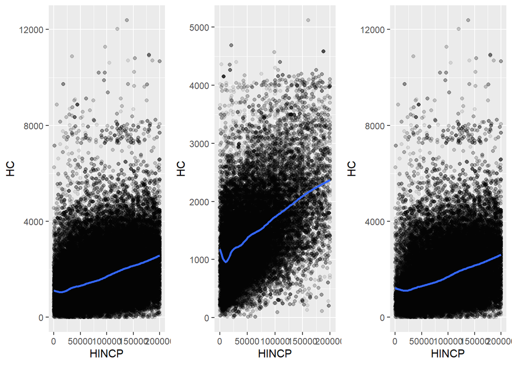

```r
plot1 <- ggplot(all_hh, aes(x = HINCP, y = HC)) +
            geom_point(alpha = 0.1) +
            geom_smooth()

plot2 <- ggplot(hh_rent, aes(x = HINCP, y = HC)) +
            geom_point(alpha = 0.1) +
            geom_smooth()

plot3 <- ggplot(hh_own, aes(x = HINCP, y = HC)) +
            geom_point(alpha = 0.1) +
            geom_smooth()

grid.arrange(plot1, plot2, plot3, ncol = 3, nrow = 1)
```

### Income, Housing Cost as a %

#### Test

Significant relationships:

- There is a stronger negative correlation between Income and HC as a % of Income for Renter than for Owner HHs.

```r
correla_all_hh <- cor.test(all_hh$HINCP, all_hh$HCPIP)
correla_all_hh
```

```
##
##  Pearson's product-moment correlation
##
## data:  all_hh$HINCP and all_hh$HCPIP
## t = -272.43, df = 156832, p-value < 2.2e-16
## alternative hypothesis: true correlation is not equal to 0
## 95 percent confidence interval:
##  -0.5701110 -0.5633922
## sample estimates:
##       cor
## -0.566761
```

```r
correla_hh_rent <- cor.test(hh_rent$HINCP, hh_rent$HCPIP)
correla_hh_rent
```

```
##
##  Pearson's product-moment correlation
##
## data:  hh_rent$HINCP and hh_rent$HCPIP
## t = -200.21, df = 55733, p-value < 2.2e-16
## alternative hypothesis: true correlation is not equal to 0
## 95 percent confidence interval:
##  -0.6516037 -0.6419456
## sample estimates:
##        cor
## -0.6468006
```

```r
correla_hh_own <- cor.test(hh_own$HINCP, hh_own$HCPIP)
correla_hh_own
```

```
##
##  Pearson's product-moment correlation
##
## data:  hh_own$HINCP and hh_own$HCPIP
## t = -167.75, df = 101097, p-value < 2.2e-16
## alternative hypothesis: true correlation is not equal to 0
## 95 percent confidence interval:
##  -0.4714388 -0.4617948
## sample estimates:
##        cor
## -0.4666307
```

#### Visualizations

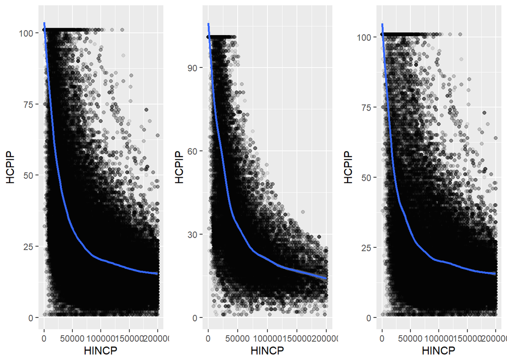

```r
plot4 <- ggplot(all_hh, aes(x = HINCP, y = HCPIP)) +
            geom_point(alpha = 0.1) +
            geom_smooth()

plot5 <- ggplot(hh_rent, aes(x = HINCP, y = HCPIP)) +
            geom_point(alpha = 0.1) +
            geom_smooth()

plot6 <- ggplot(hh_own, aes(x = HINCP, y = HCPIP)) +
            geom_point(alpha = 0.1) +
            geom_smooth()

grid.arrange(plot4, plot5, plot6, ncol = 3, nrow = 1)
```

### No. of People in HH, Income

Significant Relationships:

- All fairly weak correlations. But there is a stronger positive correlation between Income and Number of People in HH for Owner HHs than for Renter HHs. So for Owner HHs, as Number of People in HH increases, Income increases slightly more dramatically.

```r
correla_all_hh <- cor.test(all_hh$NP, all_hh$HINCP)
correla_all_hh
```

```
##
##  Pearson's product-moment correlation
##
## data:  all_hh$NP and all_hh$HINCP
## t = 83.54, df = 156832, p-value < 2.2e-16
## alternative hypothesis: true correlation is not equal to 0
## 95 percent confidence interval:
##  0.2016632 0.2111397
## sample estimates:
##       cor
## 0.2064063
```

```r
correla_hh_rent <- cor.test(hh_rent$NP, hh_rent$HINCP)
correla_hh_rent
```

```
##
##  Pearson's product-moment correlation
##
## data:  hh_rent$NP and hh_rent$HINCP
## t = 32.001, df = 55733, p-value < 2.2e-16
## alternative hypothesis: true correlation is not equal to 0
## 95 percent confidence interval:
##  0.1261612 0.1424657
## sample estimates:
##       cor
## 0.1343225
```

```r
correla_hh_own <- cor.test(hh_own$NP, hh_own$HINCP)
correla_hh_own
```

```
##
##  Pearson's product-moment correlation
##
## data:  hh_own$NP and hh_own$HINCP
## t = 85.938, df = 101097, p-value < 2.2e-16
## alternative hypothesis: true correlation is not equal to 0
## 95 percent confidence interval:
##  0.2551658 0.2666549
## sample estimates:
##       cor
## 0.2609196
```

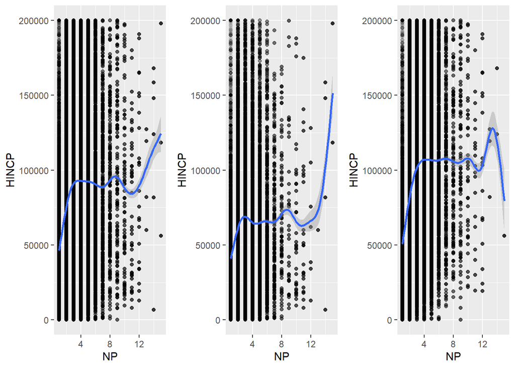

```r
plot7<- ggplot(all_hh, aes(x = NP, y = HINCP)) +
            geom_point(alpha = 0.1) +
            geom_smooth()

plot8 <- ggplot(hh_rent, aes(x = NP, y = HINCP)) +
            geom_point(alpha = 0.1) +
            geom_smooth()

plot9 <- ggplot(hh_own, aes(x = NP, y = HINCP)) +
            geom_point(alpha = 0.1) +
            geom_smooth()

grid.arrange(plot7, plot8, plot9, ncol = 3, nrow = 1)
```

### No. of People in HH, Housing Cost

Significant Relationships:

- All fairly weak correlations. There is a slightly stronger positive correlation for Owner HHs than for Renter HHs. In other words, Owner HHs with more people experience a slightly more dramatic rise in Housing Cost than Renter HHs with more people do.

```r
correla_all_hh <- cor.test(all_hh$NP, all_hh$HC)
correla_all_hh
```

```
##
##  Pearson's product-moment correlation
##
## data:  all_hh$NP and all_hh$HC
## t = 93.466, df = 156832, p-value < 2.2e-16
## alternative hypothesis: true correlation is not equal to 0
## 95 percent confidence interval:
##  0.2250093 0.2343853
## sample estimates:
##       cor
## 0.2297026
```

```r
correla_hh_rent <- cor.test(hh_rent$NP, hh_rent$HC)
correla_hh_rent
```

```
##
##  Pearson's product-moment correlation
##
## data:  hh_rent$NP and hh_rent$HC
## t = 39.938, df = 55733, p-value < 2.2e-16
## alternative hypothesis: true correlation is not equal to 0
## 95 percent confidence interval:
##  0.1587214 0.1748636
## sample estimates:
##       cor
## 0.1668037
```

```r
correla_hh_own <- cor.test(hh_own$NP, hh_own$HC)
correla_hh_own
```

```
##
##  Pearson's product-moment correlation
##
## data:  hh_own$NP and hh_own$HC
## t = 87.495, df = 101097, p-value < 2.2e-16
## alternative hypothesis: true correlation is not equal to 0
## 95 percent confidence interval:
##  0.2595768 0.2710374
## sample estimates:
##       cor
## 0.2653164
```